# xwMOOC 자연어 처리 - 텍스트

아마존 vs. 구글

# 1 아마존 vs. 구글 평판 데이터 [^1]

본 학습내용은 [Ted Kwartler, “Text Mining: Bag of Words”, DataCamp](https://www.datacamp.com/courses/intro-to-text-mining-bag-of-words)의 내용을 바탕으로 재작성한 것을 밝혀둡니다.

텍스트 데이터 분석 작업 흐름도 일반적인 데이터 분석 과정과 크게 차이가 나지는 않는다.

1. 문제 정의 및 목표설정: 적용분야 전문지식 습득 필요
2. 수집 텍스트 데이터 식별: 목표달성을 위한 정보가 담긴 데이터 발굴
3. 데이터 분석 및 모형 개발 과정
   - 텍스트 데이터 전처리 및 구조화
   - 데이터 정제 및 Feature 공학을 통한 Feature 추출
   - 데이터 분석 및 모형 개발 : 탐색적 데이터 분석 포함
4. 분석결과 정리: 보고서, 추천, 통찰 도출

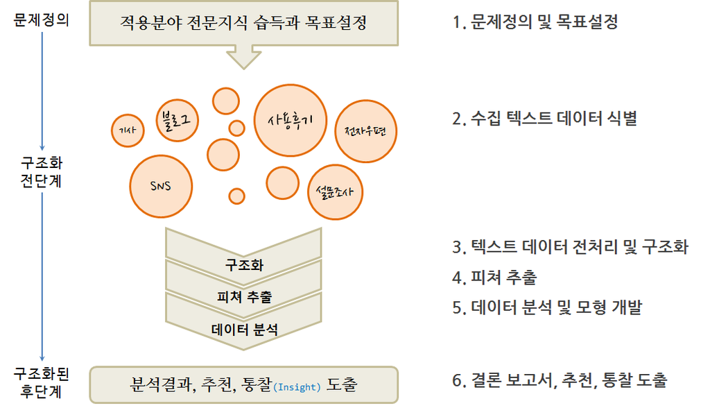

# 2 텍스트 마이닝

## 2.1 문제정의

데이터를 통해서 접근하려고 하는 문제를 다음과 같이 정의한다.

1. 온라인 리뷰에 따르면 아마존 혹은 구글 중 어느 회사가 더 좋은 연봉을 제공하는 이미지가 있는가?
2. 현재 고용된 직원의 익명 리뷰에 따르면 워라벨(일과 삶 균형)이 더 좋은 직장이 어느 곳인가?

## 2.2 텍스트 데이터

포브스를 비롯한 가장 일하기 좋은 직장에 관한 기사가 심심치 않게 나오고 있고, 한국도 예외는 아니다. 매일경제 [대한민국 일하기 좋은 100대 기업 - “직원에게 기쁨 주는 회사…일자리도 쑥쑥 느네요”](http://news.mk.co.kr/newsRead.php?year=2017&no=744993)라는 기사가 구글 검색에서 우선 나오네요. 미국의 경우 [Indeed](http://www.indeed.com/cmp/Amazon.com/reviews), [Glassdoor](http://www.glassdoor.com/), [CareerBliss](http://www.careerbliss.com/amazon/reviews/)가 있고, 국내의 경우 [“익명SNS 블라인드를 아시나요”…뒷담화 전성시대?](https://news.joins.com/article/19519738) 중앙일보 기사에 내용이 잘 정리되어 있다.

[William Surles (2017-09-25), “Text Mining: Bag of Words”](https://rpubs.com/williamsurles/316682) Rpubs 웹페이지에서 [glassdoor](https://www.glassdoor.com/) 아마존, 구글에 대한 리뷰를 받아볼 수 있다.

```r
> library(tidyverse)
> amzn_df <- read_csv('https://assets.datacamp.com/production/course_935/datasets/500_amzn.csv')
> goog_df <- read_csv('https://assets.datacamp.com/production/course_935/datasets/500_goog.csv')
>
> # amzn_df %>% write_csv("data/amzn_df.csv")
> # goog_df %>% write_csv("data/goog_df.csv")
>
> amzn_df %>%
+     sample_n(3) %>% DT::datatable()
```

|  | pg_num | url | pros | cons |
| --- | --- | --- | --- | --- |
| 1 | 60 | https://www.glassdoor.com/Reviews/Amazon-com-Reviews-E6036_P60.htm | Great place to work for extra money and good part time job | Too many bosses in one place |
| 2 | 50 | https://www.glassdoor.com/Reviews/Amazon-com-Reviews-E6036_P50.htm | The salary is good for the work involved. They offer stock however only after a year of employment at the company. | Management and Human Resources do not communicate to floor employees. The culture there seems to adhere to a he said/she said and if you are young and inexperienced in the work environment you will be… |
| 3 | 31 | https://www.glassdoor.com/Reviews/Amazon-com-Reviews-E6036_P31.htm | Benefits are really great | Communication between the customer service site and the "heads of the business" in Seattle could be better |

## 2.3 텍스트 데이터 구조화

아마존과 구글에 대한 좋은 점과 나쁜 점에 대한 평판 텍스트 데이터가 수집되었다면, 다음 단계로 텍스트 데이터 분석을 위해 데이터를 정제할 필요가 있다.

[figure not shown]

데이터프레임 구글과 아마존의 텍스트 데이터를 받아 `dqap`으로 텍스트 데이터를 바로 처리하고, `tm` 팩키지로 불용어 처리 등을 함께 처리하여 탐색적 텍스트 데이터 분석이 가능한 형태로 정제한다.

```r
> library(qdap)
> library(tm)
> # qdap 텍스트 정제
> qdap_clean <- function(x) {
+   x <- replace_abbreviation(x)
+   x <- replace_contraction(x)
+   x <- replace_number(x)
+   x <- replace_ordinal(x)
+   x <- replace_symbol(x)
+   x <- tolower(x)
+   return(x)
+ }
>
> # tm 말뭉치 생성
> tm_clean <- function(corpus) {
+   corpus <- tm_map(corpus, removePunctuation)
+   corpus <- tm_map(corpus, stripWhitespace)
+   corpus <- tm_map(corpus, removeWords,
+                    c(stopwords("en"), "Google", "Amazon", "company"))
+   return(corpus)
+ }
```

### 2.3.1 아마존 - 장점과 단점

먼저 아마존에 대해 `qdap` 팩키지 텍스트 데이터 정제기능을 활용하여 데이터를 정제한다. 추후 [RWeka](https://cran.r-project.org/web/packages/RWeka/index.html) 토큰화에 필요한 텍스트 데이터 정제과정도 함께 진행한다. 그리고 나서, `tm` 말뭉치를 생성하고 정제 작업도 함께 수행한다.

```r
> # 아마존 장점과 단점
> amzn_pros <- qdap_clean(amzn_df$pros)
> amzn_cons <- qdap_clean(amzn_df$cons)
>
> ## NA를 NULL로 치환 - RWeka 토큰화 과정에 필요
> amzn_pros[which(is.na(amzn_pros))] <- "NULL"
> amzn_cons[which(is.na(amzn_cons))] <- "NULL"
>
> # 코퍼스 생성
> az_p_corp <- VCorpus(VectorSource(amzn_pros))
> az_c_corp <- VCorpus(VectorSource(amzn_cons))
>
> ## 데이터 정제 코퍼스 생성
> amzn_pros_corp <- tm_clean(az_p_corp)
> amzn_cons_corp <- tm_clean(az_c_corp)
```

### 2.3.2 구글 - 장점과 단점

구글에 대해서도 아마존과 동일한 과정을 거쳐서 후속 텍스트 데이터 분석을 위한 데이터 전처리 정제작업을 수행한다.

```r
> # 아마존 장점과 단점
> goog_pros <- qdap_clean(goog_df$pros)
> goog_cons <- qdap_clean(goog_df$cons)
>
> ## NA를 NULL로 치환 - RWeka 토큰화 과정에 필요
> goog_pros[which(is.na(goog_pros))] <- "NULL"
> goog_cons[which(is.na(goog_cons))] <- "NULL"
>
> # 코퍼스 생성
> goog_p_corp <- VCorpus(VectorSource(goog_pros))
> goog_c_corp <- VCorpus(VectorSource(goog_cons))
>
> ## 데이터 정제 코퍼스 생성
> goog_pros_corp <- tm_clean(goog_p_corp)
> goog_cons_corp <- tm_clean(goog_c_corp)
```

# 3 피처 추출과 분석

텍스트 데이터 피처(Feature) 추출과 분석을 함께 진행한다. 먼저 uni-gram을 수행하고 bi-gram 분석도 순차적으로 진행한다.

## 3.1 한철자(uni-gram) 분석

한철자(uni-gram) 분석을 위해서 TDM을 생성한 후에 행렬로 변환 한 후에 빈도수 분석을 수행하고 이를 단어구름으로 시각화한다.

### 3.1.1 아마존 장점

아마존을 긍정리뷰에 등장횟수가 많은 단어를 추출하여 막대그래프와 단어 구름을 통해 시각화한다.

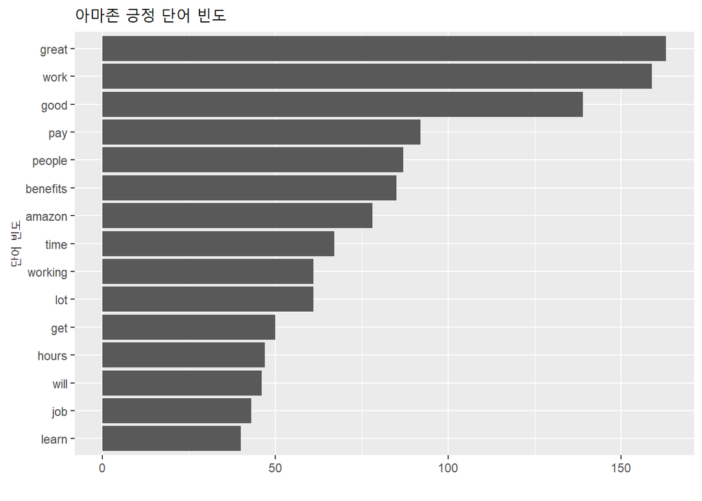

```r
> library(wordcloud)
> # TDM 생성
> amzn_p_tdm <- TermDocumentMatrix(amzn_pros_corp)
>
> # 행렬변환
> amzn_p_tdm_m <- as.matrix(amzn_p_tdm)
>
> # 빈도수 계산
> amzn_p_freq <- rowSums(amzn_p_tdm_m)
>
> # 막대그래프
> amzn_p_freq %>%
+     as.data.frame() %>%
+     rownames_to_column(var="word") %>%
+     rename(frequency = '.') %>%
+     arrange(desc(frequency)) %>%
+     top_n(15, frequency) %>%
+     ggplot(aes(x=fct_reorder(word, frequency), y=frequency)) +
+       geom_col() +
+       coord_flip() +
+       labs(x="단어 빈도", y="", title="아마존 긍정 단어 빈도")
```

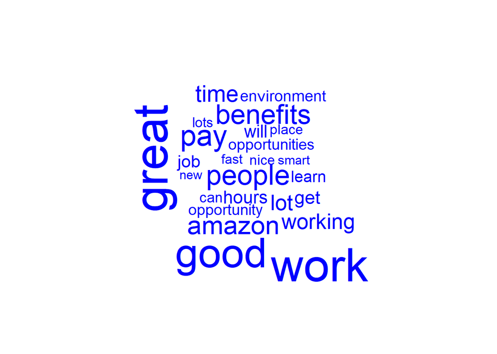

```r
> # 단어구름 생성
> wordcloud(names(amzn_p_freq),
+   amzn_p_freq,
+   max.words = 25,
+   color = "blue")
```

다음으로 유사한 단어를 하나로 묶어보자. 이를 위해서 군집분석을 수행하고 이를 수목도(dendrogram)으로 시각화한다. 단어가 25~70개 사이가 적절하고 그 이상이 되거나 그 이하가 되면 다른 방법을 찾아볼 것을 권장한다. 단어가 군집분석 수목도를 통해 적절한 단어수가 되도록 `removeSparseTerms()` 함수의 `sparse`인자값을 적절히 선택한다. 그리고 나서 `hclust` 함수로 군집분석을 수행하고 시각화를 위해 `dendextend` 팩키지를 사용하여 관심있는 단어를 묶어 채색하고 군집 갯수에 따라 단어를 묶어낸다.

[figure not shown]

```r
> library(dendextend)
> amzn_p_sparse_tdm <- removeSparseTerms(amzn_p_tdm, sparse = .97)
>
> amzn_p_hc <- hclust(
+   d = dist(amzn_p_sparse_tdm, method = "euclidean"),
+   method = "complete")
>
> amzn_p_hc_dend <- as.dendrogram(amzn_p_hc)
>
> # labels(amzn_p_hc_dend)
> amzn_p_hc_dend <- branches_attr_by_labels(amzn_p_hc_dend, c("fast", "paced"), color="black")
>
> plot(amzn_p_hc_dend)
> rect.dendrogram(amzn_p_hc_dend, k=5, color="blue")
```

### 3.1.2 아마존 단점

아마존을 부정리뷰에 등장횟수가 많은 단어를 추출하여 막대그래프와 단어 구름을 통해 시각화한다.

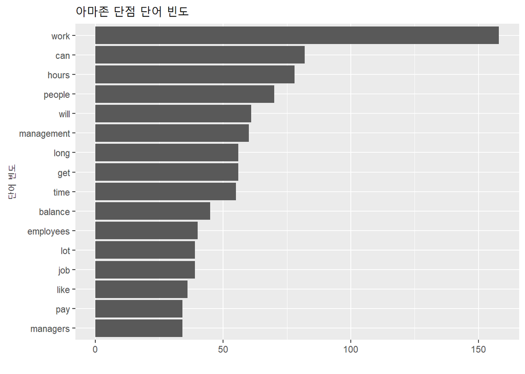

```r
> # TDM 생성
> amzn_c_tdm <- TermDocumentMatrix(amzn_cons_corp)
>
> # 행렬변환
> amzn_c_tdm_m <- as.matrix(amzn_c_tdm)
>
> # 빈도수 계산
> amzn_c_freq <- rowSums(amzn_c_tdm_m)
>
> # 막대그래프
> amzn_c_freq %>%
+     as.data.frame() %>%
+     rownames_to_column(var="word") %>%
+     rename(frequency = '.') %>%
+     arrange(desc(frequency)) %>%
+     top_n(15, frequency) %>%
+     ggplot(aes(x=fct_reorder(word, frequency), y=frequency)) +
+       geom_col() +
+       coord_flip() +
+       labs(x="단어 빈도", y="", title="아마존 단점 단어 빈도")
```

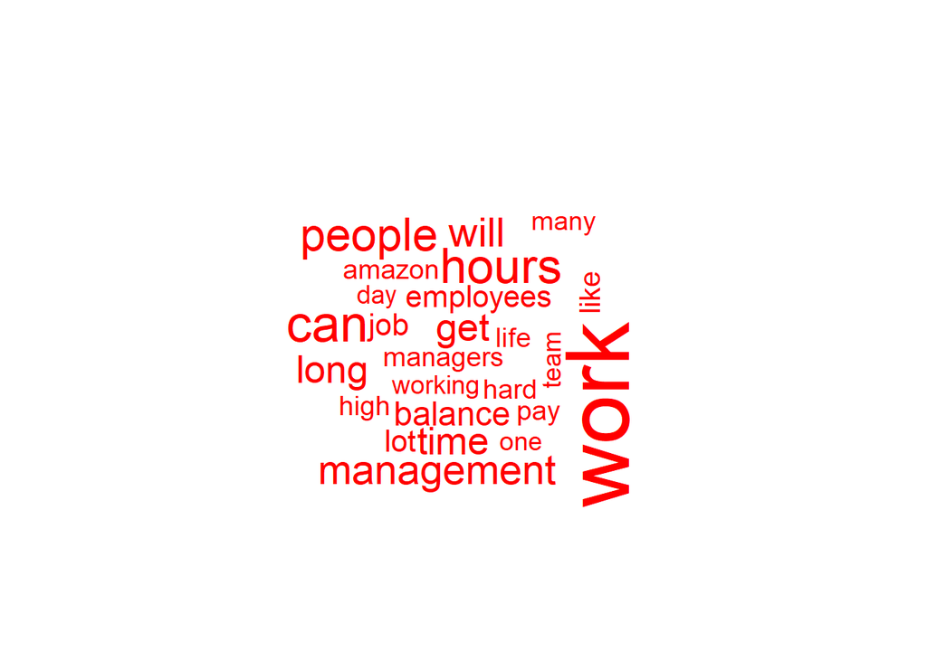

```r
> # 단어구름 생성
> wordcloud(names(amzn_c_freq),
+   amzn_c_freq,
+   max.words = 25,
+   color = "red")
```

아마존 단점을 언급한 리뷰에 대한 단어 군집분석도 유사하게 진행한다.

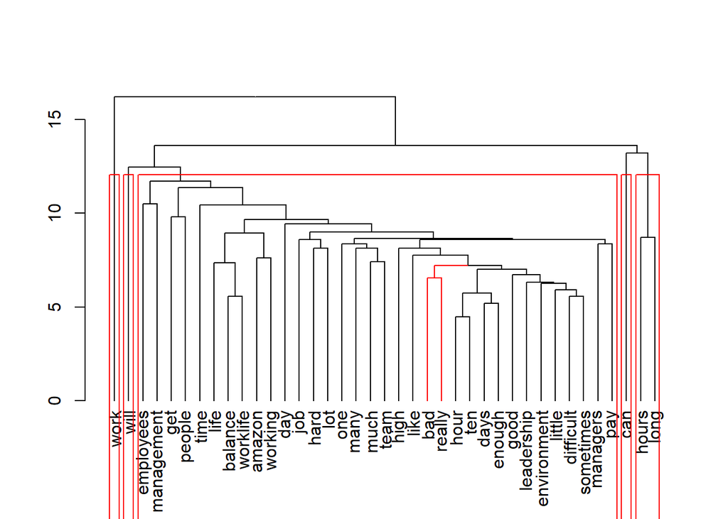

```r
> amzn_c_sparse_tdm <- removeSparseTerms(amzn_c_tdm, sparse = .97)
>
> amzn_c_hc <- hclust(
+   d = dist(amzn_c_sparse_tdm, method = "euclidean"),
+   method = "complete")
>
> amzn_c_hc_dend <- as.dendrogram(amzn_c_hc)
>
> # labels(amzn_c_hc_dend)
> amzn_c_hc_dend <- branches_attr_by_labels(amzn_c_hc_dend, c("bad", "really"), color="red")
>
> plot(amzn_c_hc_dend)
> rect.dendrogram(amzn_c_hc_dend, k=5, color="red")
```

### 3.1.3 구글 장점

구글을 긍정리뷰에 등장횟수가 많은 단어를 추출하여 막대그래프와 단어 구름을 통해 시각화한다.

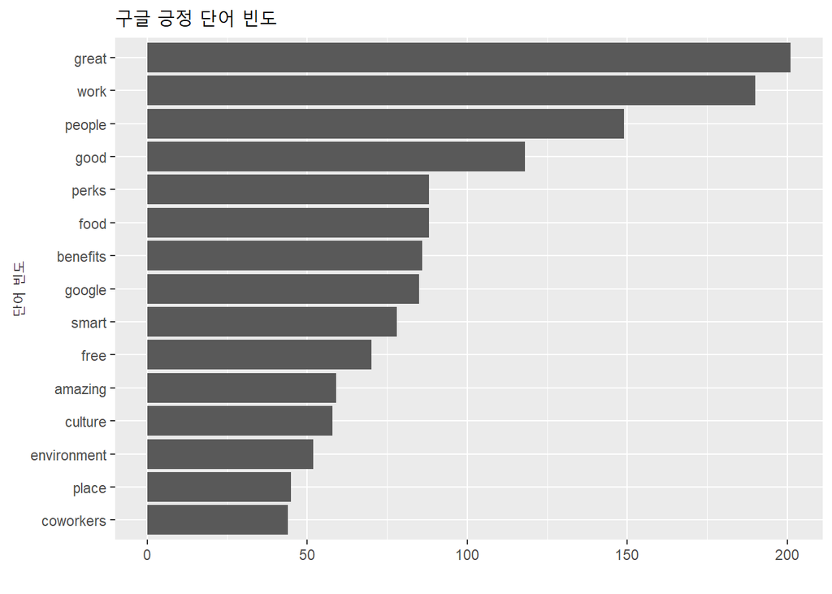

```r
> # TDM 생성
> goog_p_tdm <- TermDocumentMatrix(goog_pros_corp)
>
> # 행렬변환
> goog_p_tdm_m <- as.matrix(goog_p_tdm)
>
> # 빈도수 계산
> goog_p_freq <- rowSums(goog_p_tdm_m)
>
> # 막대그래프
> goog_p_freq %>%
+     as.data.frame() %>%
+     rownames_to_column(var="word") %>%
+     rename(frequency = '.') %>%
+     arrange(desc(frequency)) %>%
+     top_n(15, frequency) %>%
+     ggplot(aes(x=fct_reorder(word, frequency), y=frequency)) +
+       geom_col() +
+       coord_flip() +
+       labs(x="단어 빈도", y="", title="구글 긍정 단어 빈도")
```

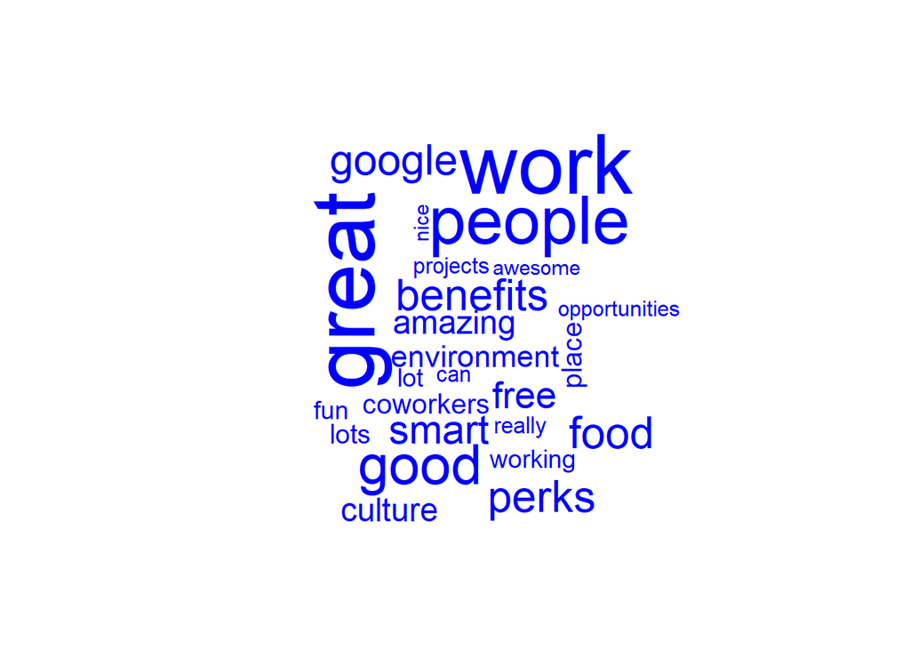

```r
> # 단어구름 생성
> wordcloud(names(goog_p_freq),
+   goog_p_freq,
+   max.words = 25,
+   color = "blue")
```

### 3.1.4 구글 단점

구글을 부정리뷰에 등장횟수가 많은 단어를 추출하여 막대그래프와 단어 구름을 통해 시각화한다.

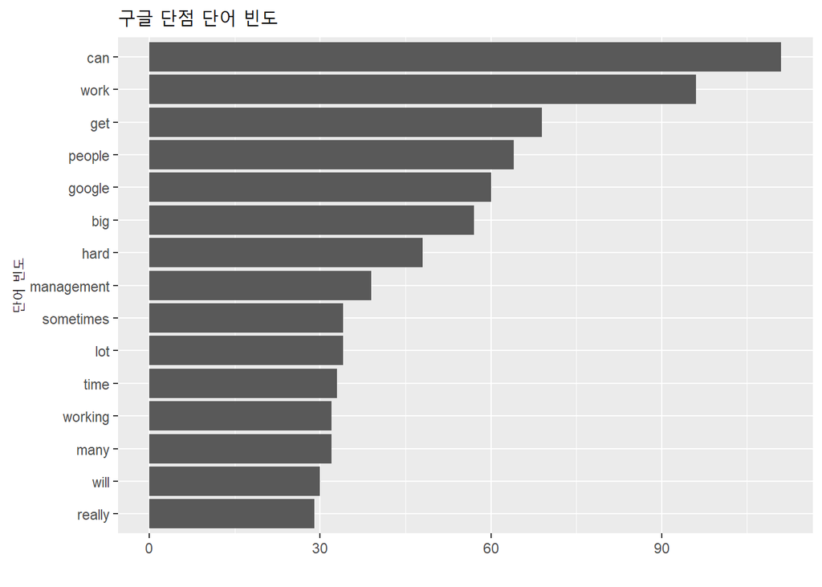

```r
> # TDM 생성
> goog_c_tdm <- TermDocumentMatrix(goog_cons_corp)
>
> # 행렬변환
> goog_c_tdm_m <- as.matrix(goog_c_tdm)
>
> # 빈도수 계산
> goog_c_freq <- rowSums(goog_c_tdm_m)
>
> # 막대그래프
> goog_c_freq %>%
+     as.data.frame() %>%
+     rownames_to_column(var="word") %>%
+     rename(frequency = '.') %>%
+     arrange(desc(frequency)) %>%
+     top_n(15, frequency) %>%
+     ggplot(aes(x=fct_reorder(word, frequency), y=frequency)) +
+       geom_col() +
+       coord_flip() +
+       labs(x="단어 빈도", y="", title="구글 단점 단어 빈도")
```

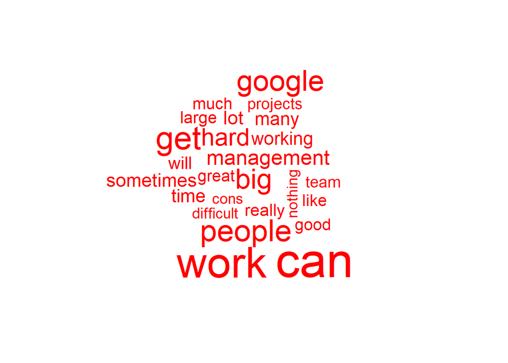

```r
> # 단어구름 생성
> wordcloud(names(goog_c_freq),
+   goog_c_freq,
+   max.words = 25,
+   color = "red")
```

## 3.2 두철자(bi-gram) 분석

한철자(uni-gram) 분석을 확장하여 두철자를 분석해 보자. 이를 위해서 앞서 아껴둔 RWeka 팩키지 토큰화 함수를 사용한다.

### 3.2.1 아마존 장단점

먼저 아마존 장단점을 한번에 볼 수 있는 단어구름을 생성한다. `NGramTokenizer` 함수를 사용해서 두철자 단어 빈도수를 계산한다. 이어서 단어구름에 넣어 아마존 장단점에 대한 시각화를 동시에 한다.

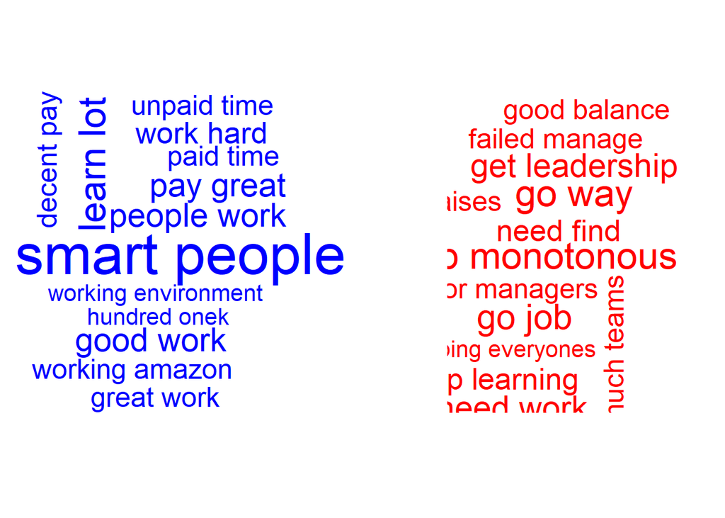

```r
> library(RWeka)
> # 토큰화
> tokenizer <- function(x) {
+     NGramTokenizer(x, Weka_control(min = 2, max = 2))
+ }
>
> # 장점 -----
> ## TDM 생성
> amzn_p_bi_tdm <- TermDocumentMatrix(amzn_pros_corp,
+                                     control = list(tokenize = tokenizer))
>
> ## 행렬변환
> amzn_p_bi_tdm_m <- as.matrix(amzn_p_bi_tdm)
>
> ## 빈도수 분석
> amzn_p_bi_freq <- rowSums(amzn_p_bi_tdm_m)
>
> # 단점 -----
> ## TDM 생성
> amzn_c_bi_tdm <- TermDocumentMatrix(amzn_cons_corp,
+                                     control = list(tokenize = tokenizer))
>
> ## 행렬변환
> amzn_c_bi_tdm_m <- as.matrix(amzn_c_bi_tdm)
>
> ## 빈도수 분석
> amzn_c_bi_freq <- rowSums(amzn_c_bi_tdm_m)
>
> # 장단점 단어구름 -----
> par(mfrow=c(1,2))
> ## 단어구름 시각화
> wordcloud(names(amzn_p_bi_freq),
+   amzn_p_bi_freq,
+   max.words = 25,
+   color = "blue")
>
> wordcloud(names(amzn_c_bi_freq),
+   amzn_p_bi_freq,
+   max.words = 25,
+   color = "red")
```

## 3.3 단어 연관성

`findAssocs()` 함수로 특정 단어 “fast paced”와 연관된 단어를 추출하고, 이를 `igraph`를 통해 시각화도 가능하다.

```r
> library(igraph)
> sort(amzn_p_bi_freq, decreasing=TRUE)[1:5]
```

```
      good pay great benefits   smart people     place work     fast paced
            25             24             20             17             16
```

```r
> sort(amzn_c_bi_freq, decreasing=TRUE)[1:5]
```

```
      long hours        work life worklife balance     life balance
              29               21               21               20
         can get
               9
```

```r
> pros_associations <- findAssocs(amzn_p_bi_tdm, "fast paced", 0.23)
>
> list_vect2df(pros_associations, col2 = "word", col3="score") %>%
+     arrange(desc(score)) %>%
+     DT::datatable()
```

|  | X1 | word | score |
| --- | --- | --- | --- |
| 1 | fast paced | paced environment | 0.49 |
| 2 | fast paced | environments ever | 0.35 |
| 3 | fast paced | learn fast | 0.35 |
| 4 | fast paced | paced friendly | 0.35 |
| 5 | fast paced | paced work | 0.35 |
| 6 | fast paced | able excel | 0.25 |
| 7 | fast paced | activity ample | 0.25 |
| 8 | fast paced | advance one | 0.25 |
| 9 | fast paced | also well | 0.25 |
| 10 | fast paced | amazon fast | 0.25 |

[output cut: 129 more lines]

[figure not shown]

```r
> par(mfrow=c(1,1))
>
> amzn_g <- graph.data.frame(list_vect2df(pros_associations, col2 = "word", col3="score"), directed = TRUE)
>
> plot(amzn_g,
+      edge.arrow.size=.2,
+      edge.color="orange",
+      vertex.color="dark gray",
+      vertex.frame.color="#ffffff",
+      vertex.label=V(amzn_g)$name, vertex.label.color="black")
```

## 3.4 사내 장단점 비교

사내 장단점 비교를 위해서 `comparison.cloud`를 사용해서 구글의 장담점, 아마존의 장단점을 파악해 보자.

### 3.4.1 구글 장단점

구글의 장단점 리뷰를 한데 묶어 말뭉치를 만들고 TDM 으로 변환하여 `comparison.cloud`에 넣어 장단점을 시각화한다.

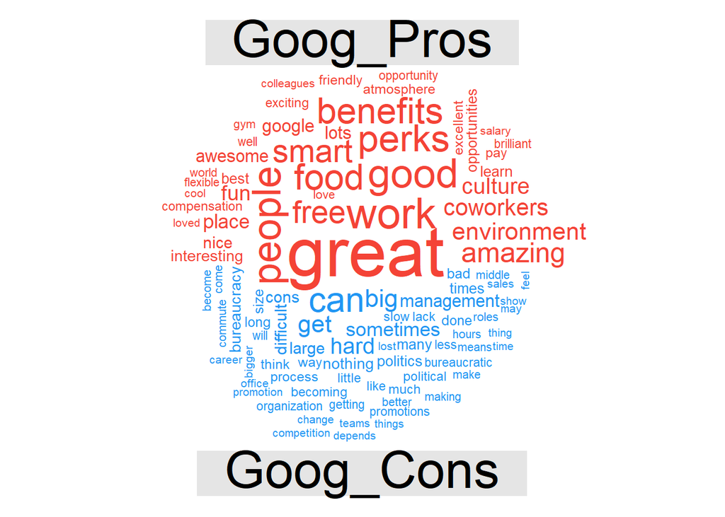

```r
> ## qdap 텍스트 정제
> goog_df$qdap_pros <- qdap_clean(goog_df$pros)
> goog_df$qdap_cons <- qdap_clean(goog_df$cons)
>
> ## tm 텍스트 정제
> goog_corpus <- VCorpus(VectorSource(goog_df[,5:6]))
> goog_corp <- tm_clean(goog_corpus)
>
> ## TDM 변환
> goog_tdm <- TermDocumentMatrix(goog_corp)
> colnames(goog_tdm) <- c("Goog_Pros", "Goog_Cons")
>
> goog_m <- as.matrix(goog_tdm)
>
> ## 비교단어구름 시각화
> comparison.cloud(goog_m,
+   colors = c("#F44336", "#2196f3"),
+   max.words = 100)
```

### 3.4.2 아마존 장단점

아마존의 장단점 리뷰를 한데 묶어 말뭉치를 만들고 TDM 으로 변환하여 `comparison.cloud`에 넣어 장단점을 시각화한다.

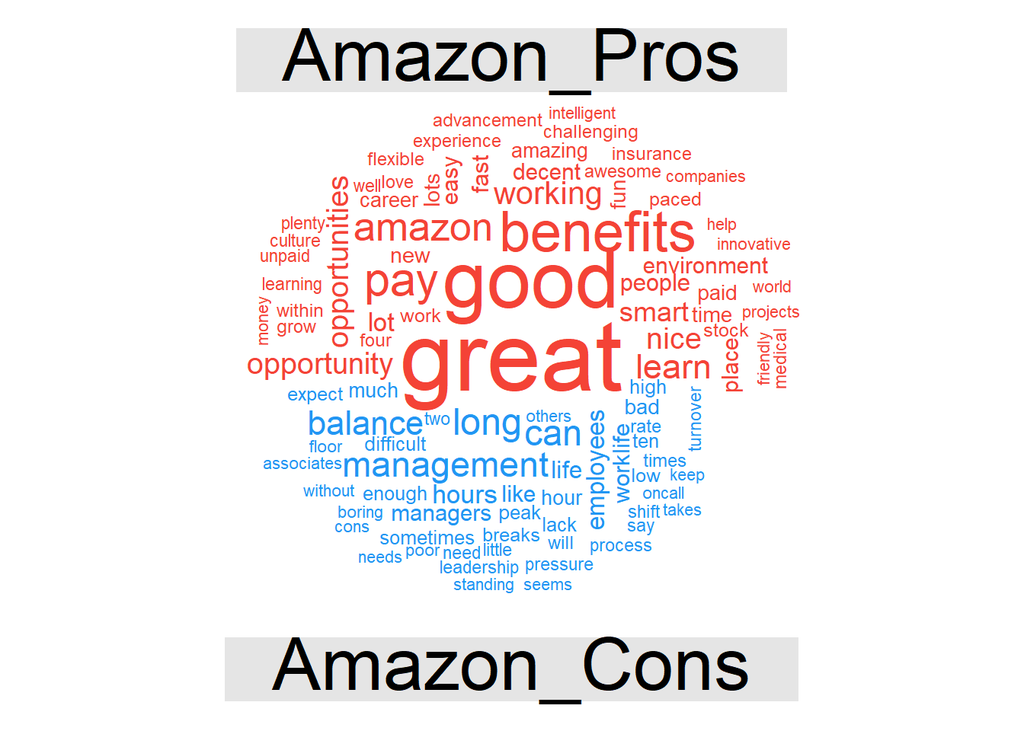

```r
> ## qdap 텍스트 정제
> amzn_df$qdap_pros <- qdap_clean(amzn_df$pros)
> amzn_df$qdap_cons <- qdap_clean(amzn_df$cons)
>
> ## tm 텍스트 정제
> amzn_corpus <- VCorpus(VectorSource(amzn_df[,5:6]))
> amzn_corp <- tm_clean(amzn_corpus)
>
> ## TDM 변환
> amzn_tdm <- TermDocumentMatrix(amzn_corp)
> colnames(amzn_tdm) <- c("Amazon_Pros", "Amazon_Cons")
>
> amzn_m <- as.matrix(amzn_tdm)
>
> ## 비교단어구름 시각화
> comparison.cloud(amzn_m,
+   colors = c("#F44336", "#2196f3"),
+   max.words = 100)
```

## 3.5 회사간 비교

장점과 단점을 회사간 비교를 위해서 `pyramid.plot`를 사용해서 구글과 아마존을 비교해서 우열을 파악해보자.

### 3.5.1 긍정

아마존과 구글 긍정리뷰를 데이터프레임으로 생성해서 데이터 정제작업을 수행하고 두철자(bigram) 토큰화과정을 거쳐 TDM을 생성해서 행렬로 변환시킨다.

```r
> pros_df <- data.frame(
+   amzn_pros = c(as.character(amzn_df$pros), 'NULL'),
+   goog_pros = as.character(goog_df$pros),
+   stringsAsFactors = FALSE
+ )
>
> pros_df[is.na(pros_df)] <- "NULL"
> pros_df <- qdap_clean(pros_df)
>
> all_pros_corpus <- VCorpus(VectorSource(pros_df))
> all_pros_corp <- tm_clean(all_pros_corpus)
>
> all_pros_tdm <- TermDocumentMatrix(
+   all_pros_corp,
+   control = list(tokenize = tokenizer)
+ )
>
> all_pros_tdm_m <- as.matrix(all_pros_tdm)
```

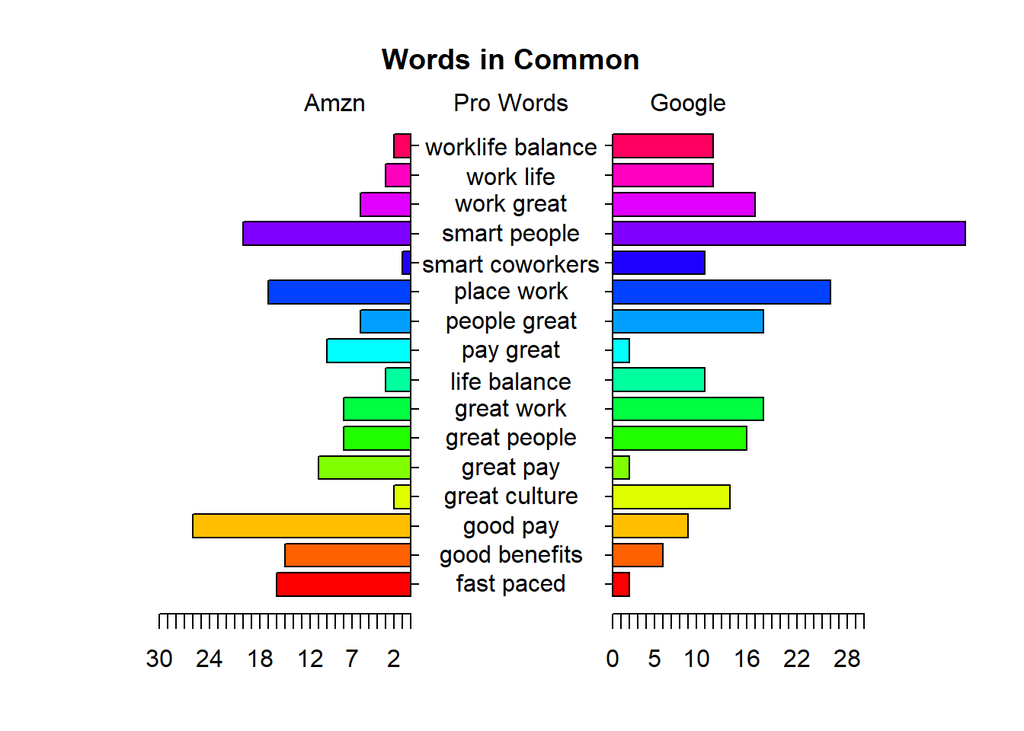

```
[1] 5.1 4.1 4.1 2.1
```

```r
> library(plotrix)
> top_df <- all_pros_tdm_m %>% as.data.frame %>%
+     rownames_to_column(var="words") %>%
+     tbl_df %>%
+     rename(amazon_pro = `1`,
+            google_pro = `2`) %>%
+     filter(amazon_pro != 0,
+            google_pro !=0) %>%
+     mutate(diff = abs(amazon_pro - google_pro)) %>%
+     top_n(15, diff)
>
>
> # Create the pyramid plot
> pyramid.plot(top_df$amazon_pro, top_df$google_pro,
+              labels = top_df$words,
+              gap = 12,
+              top.labels = c("Amzn", "Pro Words", "Google"),
+              main = "Words in Common", unit = NULL)
```

### 3.5.2 부정

동일하게 아마존과 구글 부정리뷰를 데이터프레임으로 생성해서 데이터 정제작업을 수행하고 두철자(bigram) 토큰화과정을 거쳐 TDM을 생성해서 행렬로 변환시킨다.

```r
> cons_df <- data.frame(
+   amzn_cons = c(as.character(amzn_df$qdap_cons), 'NULL'),
+   goog_cons = as.character(goog_df$qdap_cons),
+   stringsAsFactors = FALSE
+ )
>
> cons_df$amzn_cons[which(is.na(cons_df$amzn_cons))] <- "NULL"
> cons_df$goog_cons[which(is.na(cons_df$goog_cons))] <- "NULL"
>
> all_cons_corpus <- VCorpus(VectorSource(cons_df))
> all_cons_corp <- tm_clean(all_cons_corpus)
>
> all_cons_tdm <- TermDocumentMatrix(
+   all_cons_corp,
+   control = list(tokenize = tokenizer)
+ )
>
> all_cons_tdm_m <- as.matrix(all_cons_tdm)
```

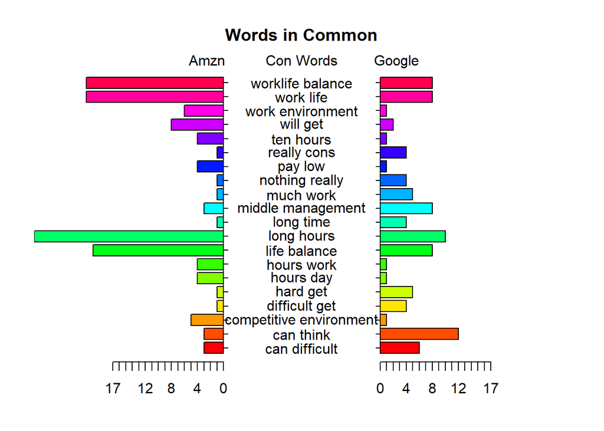

```
[1] 5.1 4.1 4.1 2.1
```

```r
> top_cons_df <- all_cons_tdm_m %>% as.data.frame %>%
+     rownames_to_column(var="words") %>%
+     tbl_df %>%
+     rename(amazon_con = `1`,
+            google_con = `2`) %>%
+     filter(amazon_con != 0,
+            google_con !=0) %>%
+     mutate(diff = abs(amazon_con- google_con)) %>%
+     top_n(15, diff)
>
>
> # Create the pyramid plot
> pyramid.plot(top_cons_df$amazon_con, top_cons_df$google_con,
+              labels = top_cons_df$words,
+              gap = 12,
+              top.labels = c("Amzn", "Con Words", "Google"),
+              main = "Words in Common", unit = NULL)
```

# 4 결론

단어주머니 텍스트 데이터 분석을 통해서 구글이 워라밸이 아마존보다 좋은 듯 싶다. 아마존 인사담당자는 학습능력이 뛰어나고 성장할 수 있는 기회가 많이 주어지나 상대적으로 업무강도가 센 직업을 선호하는 사람을 직원으로 채용하는 것을 추천한다.

[^1]: [William Surles (2017-09-25), “Text Mining: Bag of Words”](https://rpubs.com/williamsurles/316682)